# Positron, VS Code, Other Coding IDEs, MLJAR, and AutoML

12:15–1:15 PM  
Zoom: https://csueb.zoom.us/j/88674490934  
Slides produced with the help of OpenAI Codex and pi.

Eric A. Suess

November 19, 2026

## Today’s goals

By the end of this session, you should be able to:

- Explain what an **integrated development environment (IDE)** does.
- Compare **Positron**, **Visual Studio Code**, and several other coding environments.
- Choose an environment for R, Python, notebooks, Quarto, or general programming.
- Distinguish **MLJAR Studio** from the **MLJAR AutoML** Python package.
- Describe what automated machine learning (**AutoML**) can—and cannot—do.
- Evaluate an AutoML result without treating the highest score as the whole answer.

## Four related—but different—tools

| Tool type | Main purpose | Examples |
| --- | --- | --- |
| Code editor | Write and navigate source code | Zed, basic text editors |
| IDE | Edit, run, debug, inspect, and manage projects | Positron, VS Code, RStudio |
| Notebook environment | Mix narrative, code, and output | JupyterLab, Positron notebooks |
| AutoML system | Train and compare predictive models | MLJAR AutoML |

**MLJAR Studio** crosses categories: it is a local, notebook-based AI workspace that can run AutoML experiments.

## What makes an editor an IDE?

An IDE brings common development tasks into one workspace:

- Source-code editing and completion
- R or Python consoles and terminals
- Running and debugging code
- Files, projects, and environments
- Data, plots, variables, and help
- Git source control
- Extensions and AI assistance
- Notebook, Quarto, app, or report previews

The goal is not more buttons. The goal is a shorter path from an idea to a verified result.

## Why the environment matters

A good environment helps you:

1. Use the correct R or Python installation.
2. See which files and packages belong to the project.
3. Run small pieces of code while exploring.
4. Reproduce the complete analysis later.
5. Inspect errors, data, and model output.
6. Review AI-generated changes before accepting them.

**Tip**

Choose the environment that reduces friction in **your actual workflow**, not the one with the longest feature list.

## Positron: a data science IDE

[Positron](https://positron.posit.co/) is Posit’s free, next-generation IDE purpose-built for **R and Python**.

- Built on **Code OSS**, the open-source foundation of VS Code
- Persistent R and Python consoles, including multiple sessions
- Data Explorer, Variables, Plots, and Help panes
- Jupyter notebook and Quarto support
- Tools for Shiny, Streamlit, FastAPI, and other data applications
- Integrated, data-science-aware AI assistance

Positron combines a general code editor with interactive features familiar to data scientists.

## Positron’s data science workflow

A typical workflow stays inside one project:

**Write code** → **run in a console** → **inspect data and plots** → **revise** → **publish**

Positron is especially attractive when you:

- Regularly move between R and Python.
- Want notebook exploration and script-based development together.
- Need data viewers, plots, and variables without assembling many extensions.
- Build Quarto documents or data applications.
- Want an IDE that can also handle languages beyond R and Python.

Source: [Positron Features](https://positron.posit.co/features.html)

## Positron and RStudio

| Choose | A strong fit when… |
| --- | --- |
| **RStudio** | Your work is primarily R and you value its mature, familiar R workflow. |
| **Positron** | You want first-class R **and** Python support in a modern, extensible IDE. |

Both can support:

- R scripts, packages, and projects
- Quarto documents and presentations
- Data inspection and visualization
- Terminals, Git, and AI assistance

Positron is an additional choice—not a requirement to abandon a productive RStudio workflow.

## Visual Studio Code

[Visual Studio Code](https://code.visualstudio.com/) is a general-purpose editor with IDE capabilities supplied by built-in tools and extensions.

- Runs on Windows, macOS, and Linux
- Editing, IntelliSense, debugging, terminal, tasks, and Git
- Large extension ecosystem for many languages and workflows
- Local, remote, container, and cloud development options
- Jupyter notebooks through the Jupyter extension
- AI chat, completion, and agent workflows

**Note**

**Visual Studio Code** is not the same product as the larger **Visual Studio** IDE.

## Using R in VS Code

A practical R setup usually requires:

1. Install R.
2. Install the **R extension** for VS Code.
3. Install the R package `languageserver`.
4. Optionally add tools such as `radian` and `httpgd`.
5. Install the Quarto extension when authoring `.qmd` files.
6. Select and test the intended R executable.

VS Code can then send code to an R terminal and display data, plots, workspace variables, and help.

Source: [R in Visual Studio Code](https://code.visualstudio.com/docs/languages/r)

## Positron or VS Code?

| Dimension | Positron | VS Code |
| --- | --- | --- |
| Starting point | Data science environment | General-purpose code editor |
| R and Python | First-class, built in | Added and configured with extensions |
| Data exploration | Integrated panes and consoles | Depends more on extensions |
| Other languages | Extensible | Very broad extension ecosystem |
| Customization | Strong | Extensive |
| Best fit | Data analysis, notebooks, apps, Quarto | Polyglot software and highly customized workflows |

Because Positron is built on Code OSS, the interfaces feel related—but their defaults and intended audiences differ.

## Other environments worth knowing

| Environment | Best known for |
| --- | --- |
| **RStudio** | A mature, integrated R data science workflow |
| **JupyterLab** | Browser-based computational notebooks, kernels, and interactive exploration |
| **Zed** | A fast, open-source code editor with collaboration and AI tools |
| **PyCharm** | Full-featured Python development, navigation, testing, and debugging |
| **Google Colab** | Hosted Jupyter notebooks with easy sharing and cloud compute |

“Best” depends on language, collaboration, institutional support, compute location, and the artifact you need to produce.

## A simple choice guide

- **Mostly R?** Begin with RStudio; also try Positron.
- **R + Python data science?** Try Positron.
- **Many programming languages or specialized extensions?** Try VS Code.
- **Notebook-first teaching or exploration?** Try JupyterLab or Colab.
- **Python application development?** Compare VS Code and PyCharm.
- **Fast editing and collaboration?** Consider Zed.

You can use more than one tool, but avoid changing environments merely because a new one appears.

## Live IDE demonstration

Open the same Quarto project in Positron and VS Code, then compare:

1. File and project navigation
2. Selecting the R interpreter
3. Sending R code to the console
4. Viewing a data frame and a plot
5. Opening a terminal
6. Previewing a Quarto presentation
7. Reviewing Git changes
8. Asking an AI assistant to explain—not silently replace—the code

**Question:** Which steps work immediately, and which require configuration?

## What is MLJAR Studio?

[MLJAR Studio](https://mljar.com/) is a local, Python notebook workspace with AI-assisted data analysis.

- Ask questions in natural language and receive visible Python code.
- Run the generated analysis on the local computer.
- Inspect, edit, and rerun notebook code.
- Use **AutoLab Experiments** for iterative model experiments.
- Use the MLJAR AutoML package from the same workspace.
- Convert suitable notebook results into applications with Mercury.

**Important**

Local code execution does not automatically make every AI interaction private. Check the configured model provider and institutional data policy before using sensitive data.

## MLJAR Studio vs. MLJAR AutoML

| MLJAR Studio | `mljar-supervised` / MLJAR AutoML |
| --- | --- |
| Desktop data science workspace | Open-source Python package |
| Notebook and AI interface | Classification and regression automation |
| Helps generate and run Python | Preprocesses, trains, tunes, and compares models |
| Can launch experiments | Produces model documentation and diagnostics |

You can use the AutoML package inside MLJAR Studio, Positron, VS Code, JupyterLab, or another Python environment.

## What is automated machine learning?

For **supervised learning**, we have predictors $X$ and an outcome $Y$.

- **Classification:** predict a category, such as “spam” or “not spam.”
- **Regression:** predict a numeric value, such as sales or travel time.

AutoML automates repeated parts of the predictive-modeling workflow:

**preprocess** → **fit candidates** → **tune** → **validate** → **compare** → **document**

It searches a defined space. It does not remove the need to define a valid problem.

## What AutoML can automate

Depending on the tool and configuration, AutoML may:

- Impute missing values and encode categorical predictors.
- Establish a simple baseline.
- Train linear, tree-based, boosting, neural-network, or neighbor models.
- Tune hyperparameters.
- Use resampling or cross-validation.
- Build ensembles or stacked models.
- Rank models using a selected metric.
- Produce learning curves, importance measures, or SHAP explanations.
- Save models and generate reports.

Automation saves repetition; it does not guarantee a trustworthy model.

## What AutoML cannot decide for you

AutoML does not determine whether:

- The target variable represents the real question.
- The sample represents the population where the model will be used.
- A predictor leaks future or outcome information.
- The metric reflects the cost of mistakes.
- Group performance is equitable.
- Prediction should be interpreted as causation.
- Deployment is ethical, legal, secure, or useful.

These are human and institutional responsibilities.

## Protect the final test set

A defensible predictive workflow separates three roles:

| Data portion | Purpose |
| --- | --- |
| Training data | Estimate model parameters |
| Validation or resamples | Compare models and tune settings |
| Test data | Estimate final performance on untouched observations |

Repeatedly checking the test set turns it into another validation set.

**Warning**

Split by **time, person, school, patient, or site** when random row splitting would leak related information across sets.

## MLJAR AutoML modes

MLJAR provides modes with different defaults:

- **Explain:** faster exploration, interpretable models, and detailed explanations
- **Perform:** balance predictive quality, training time, and prediction speed
- **Compete:** broader search, feature engineering, ensembles, and stacking
- **Optuna:** more intensive hyperparameter optimization

Begin with **Explain** to understand the dataset and baseline. More computation is not automatically more scientific.

Source: [MLJAR AutoML](https://mljar.com/automl/) and [AutoML Modes](https://supervised.mljar.com/features/modes/)

## MLJAR AutoML: a small Python example

Install the package in the intended Python environment:

```bash
python -m pip install mljar-supervised
```

```python
from sklearn.datasets import load_iris
from sklearn.model_selection import train_test_split
from sklearn.metrics import accuracy_score
from supervised import AutoML

data = load_iris(as_frame=True)
X_train, X_test, y_train, y_test = train_test_split(
    data.data, data.target,
    test_size=0.20, stratify=data.target, random_state=310
)

automl = AutoML(
    mode="Explain",
    total_time_limit=300,
    results_path="iris_automl"
)
automl.fit(X_train, y_train)
predictions = automl.predict(X_test)
accuracy_score(y_test, predictions)
```

## Do not stop at the leaderboard

After training, inspect:

- The **baseline** and whether complex models improve on it
- The validation method and evaluation metric
- Variation across folds—not only the mean score
- Confusion matrices or residual plots
- Learning curves and signs of overfitting
- Feature importance and explanation limitations
- Errors on meaningful subgroups
- Training time, prediction time, and model complexity
- Performance on the untouched test set

The winning model may not be the model you should deploy.

## The same comparison logic in R

This teaching example manually compares four model families with five-fold cross-validation. AutoML systems automate and expand this pattern.

**Show the tidymodels code**

```r
library(tidymodels)

set.seed(310)

iris_data <- as_tibble(iris)
iris_split <- initial_split(iris_data, prop = 0.80, strata = Species)
iris_train <- training(iris_split)
iris_folds <- vfold_cv(iris_train, v = 5, strata = Species)

model_specs <- list(
  "Multinomial regression" = multinom_reg() |>
    set_engine("nnet"),
  "Decision tree" = decision_tree() |>
    set_mode("classification") |>
    set_engine("rpart"),
  "Random forest" = rand_forest(trees = 500) |>
    set_mode("classification") |>
    set_engine("ranger"),
  "Nearest neighbors" = nearest_neighbor(neighbors = 5) |>
    set_mode("classification") |>
    set_engine("kknn")
)

model_results <- purrr::imap_dfr(
  model_specs,
  \(spec, model_name) {
    workflow() |>
      add_formula(Species ~ .) |>
      add_model(spec) |>
      fit_resamples(
        resamples = iris_folds,
        metrics = metric_set(accuracy)
      ) |>
      collect_metrics() |>
      transmute(
        model = model_name,
        mean_accuracy = mean,
        std_error = std_err
      )
  }
)

model_results |>
  mutate(model = forcats::fct_reorder(model, mean_accuracy)) |>
  ggplot(aes(x = mean_accuracy, y = model)) +
  geom_col(fill = "#1f77b4", width = 0.7) +
  geom_errorbar(
    aes(
      xmin = pmax(0, mean_accuracy - std_error),
      xmax = pmin(1, mean_accuracy + std_error)
    ),
    width = 0.18,
    color = "#163a5f"
  ) +
  scale_x_continuous(limits = c(0, 1), labels = scales::percent) +
  labs(
    title = "Candidate Models on the Iris Training Data",
    subtitle = "Mean five-fold cross-validation accuracy ± one standard error",
    x = "Cross-validation accuracy",
    y = NULL,
    caption = "Teaching example: model specifications were chosen manually"
  ) +
  theme_minimal(base_size = 15)
```

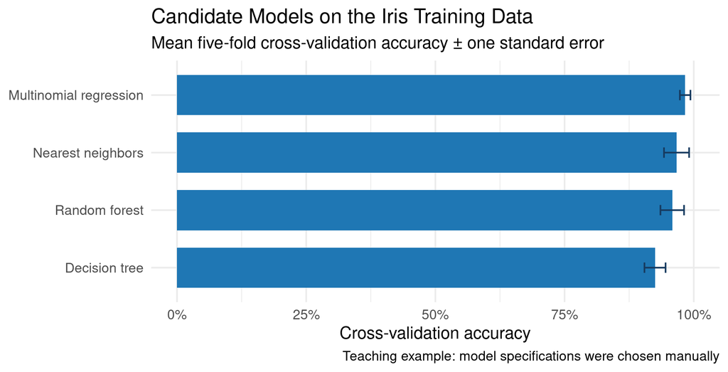

Figure 1

## tidymodels and scikit-learn: same workflow

| Modeling task | R with tidymodels | Python with scikit-learn |
| --- | --- | --- |
| Train/test split | `initial_split()` | `train_test_split()` |
| Stratified folds | `vfold_cv()` | `StratifiedKFold()` |
| Preprocessing + model | `workflow()` | `Pipeline` / `make_pipeline()` |
| Resampling | `fit_resamples()` | `cross_val_score()` |
| Accuracy | `yardstick::accuracy()` | `scoring="accuracy"` |
| Final model | `last_fit()` | `fit()` and test-set scoring |

The syntax differs, but the statistical logic is the same. Keep preprocessing inside the workflow or pipeline so it is learned separately within each training fold.

## The same comparison logic in Python

This scikit-learn example compares the same four model families using stratified five-fold cross-validation on the Iris training data.

**Show the scikit-learn code**

```python
import numpy as np
import pandas as pd
import matplotlib.pyplot as plt
from sklearn.datasets import load_iris
from sklearn.ensemble import RandomForestClassifier
from sklearn.linear_model import LogisticRegression
from sklearn.model_selection import (
    StratifiedKFold,
    cross_val_score,
    train_test_split,
)
from sklearn.neighbors import KNeighborsClassifier
from sklearn.pipeline import make_pipeline
from sklearn.preprocessing import StandardScaler
from sklearn.tree import DecisionTreeClassifier

iris_data = load_iris(as_frame=True)
X_train, X_test, y_train, y_test = train_test_split(
    iris_data.data,
    iris_data.target,
    test_size=0.20,
    stratify=iris_data.target,
    random_state=310,
)

iris_folds = StratifiedKFold(
    n_splits=5,
    shuffle=True,
    random_state=310,
)

model_specs = {
    "Multinomial logistic regression": make_pipeline(
        StandardScaler(),
        LogisticRegression(max_iter=1000),
    ),
    "Decision tree": DecisionTreeClassifier(random_state=310),
    "Random forest": RandomForestClassifier(
        n_estimators=500,
        random_state=310,
    ),
    "Nearest neighbors": make_pipeline(
        StandardScaler(),
        KNeighborsClassifier(n_neighbors=5),
    ),
}

model_results = []
for model_name, model in model_specs.items():
    fold_accuracy = cross_val_score(
        model,
        X_train,
        y_train,
        cv=iris_folds,
        scoring="accuracy",
    )
    model_results.append(
        {
            "model": model_name,
            "mean_accuracy": fold_accuracy.mean(),
            "std_error": (
                fold_accuracy.std(ddof=1) /
                np.sqrt(len(fold_accuracy))
            ),
        }
    )

model_results = (
    pd.DataFrame(model_results)
    .sort_values("mean_accuracy")
)

fig, ax = plt.subplots(figsize=(9, 4.6))
ax.barh(
    model_results["model"],
    model_results["mean_accuracy"],
    xerr=model_results["std_error"],
    color="#f28e2b",
    ecolor="#7a3e00",
    capsize=4,
)
_ = ax.set_xlim(0, 1)
_ = ax.set_xlabel("Cross-validation accuracy")
_ = ax.set_title(
    "Candidate Models on the Iris Training Data\n"
    "Mean stratified five-fold accuracy ± one standard error",
    fontweight="bold",
    fontsize=12,
    pad=10,
)
_ = ax.grid(axis="x", alpha=0.25)
_ = ax.spines[["top", "right"]].set_visible(False)
_ = fig.tight_layout()
plt.show()
```

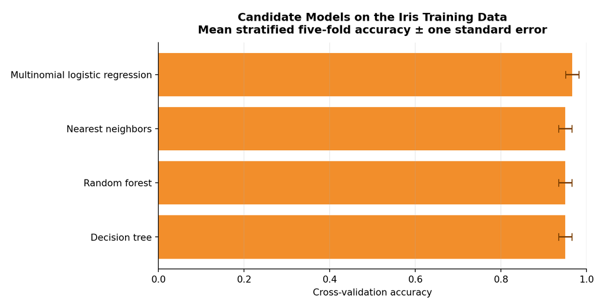

Figure 2

## What the teaching examples leave out

The comparisons are reproducible, but they are deliberately small:

- Only four manually selected specifications
- Almost no hyperparameter tuning
- One split and five folds
- Accuracy as the only metric
- A tiny, clean teaching dataset
- No subgroup, fairness, calibration, or deployment analysis

AutoML can search more broadly. Sound statistical reasoning determines whether that search answers the right question.

## A responsible AutoML checklist

Before trusting a result, document:

1. **Question:** What decision will the prediction support?
2. **Outcome:** How was the target defined and measured?
3. **Data:** Who or what is represented—and missing?
4. **Split:** Could information leak across training and evaluation?
5. **Metric:** What errors matter most?
6. **Baseline:** Does the model beat a simple rule?
7. **Uncertainty:** How stable is performance?
8. **Equity:** How does performance vary across relevant groups?
9. **Reproducibility:** Can the environment and experiment be rerun?
10. **Oversight:** Who reviews, approves, monitors, and retires the model?

## Mini-activity: choose a workspace

For each scenario, choose an environment and explain why:

1. An instructor writes only R and publishes Quarto course notes.
2. A data scientist alternates between R, Python, Shiny, and FastAPI.
3. A software team works across Python, JavaScript, containers, and remote servers.
4. A class shares browser-based notebooks with no local installation.
5. A researcher wants to compare tabular prediction models and inspect reports.

There may be more than one defensible answer. State the tradeoff.

## Key takeaways

- An IDE integrates editing, execution, debugging, projects, and supporting tools.
- Positron emphasizes first-class R and Python data science workflows.
- VS Code emphasizes broad language support and extension-driven customization.
- RStudio, JupyterLab, Zed, PyCharm, and Colab remain useful choices.
- MLJAR Studio is a local notebook and AI workspace; MLJAR AutoML is a Python package.
- AutoML automates model search—not problem formulation, data quality, or accountability.
- Protect the test set, inspect the baseline, and evaluate more than the top score.

## References

All links were accessed October 3, 2026.

- Posit: [Positron](https://positron.posit.co/), [Welcome to Positron](https://positron.posit.co/welcome.html), [Positron Features](https://positron.posit.co/features.html), and [RStudio IDE](https://posit.co/products/open-source/rstudio/)
- Microsoft: [Visual Studio Code Documentation](https://code.visualstudio.com/docs), [Why Visual Studio Code?](https://code.visualstudio.com/docs/editor/whyvscode), [R in Visual Studio Code](https://code.visualstudio.com/docs/languages/r), and [Jupyter Notebooks in VS Code](https://code.visualstudio.com/docs/datascience/jupyter-notebooks)
- MLJAR: [MLJAR Studio](https://mljar.com/), [Studio Documentation](https://mljar.com/docs/), [MLJAR AutoML](https://mljar.com/automl/), and [`mljar-supervised` Documentation](https://supervised.mljar.com/)
- Other environments: [JupyterLab](https://jupyterlab.readthedocs.io/en/stable/), [Zed](https://zed.dev/docs/), and [PyCharm](https://www.jetbrains.com/pycharm/)
- R modeling: [tidymodels](https://www.tidymodels.org/), [workflows](https://tidymodels.github.io/workflows/), [rsample](https://rsample.tidymodels.org/), and [yardstick](https://yardstick.tidymodels.org/)
- Python modeling: [scikit-learn User Guide](https://scikit-learn.org/stable/user_guide.html), [Cross-validation](https://scikit-learn.org/stable/modules/cross_validation.html), and [Pipelines](https://scikit-learn.org/stable/modules/compose.html#pipeline)

Product features, licensing, AI providers, and institutional availability can change. Verify current documentation before installation or adoption.

## Questions & discussion

**Join the Discussion**

**Date:** November 19, 2026  
**Time:** 12:15–1:15 PM  
**Zoom:** https://csueb.zoom.us/j/88674490934

- Which environment best fits your current work?
- What would you need to verify before trusting an AutoML result?